# Homework 2

## Task 1

##### Red:

With given rules we can construct a table for Red which will look like this:

| Red | Will use XAI | Will not use XAI | Total |
| --- | --- | --- | --- |
| Enrolled in training | 25 | 25 | 50 |
| not enrolled in training | 25 | 25 | 50 |
| Total | 50 | 50 | 100 |

Positive rate: 50 / 100 = 0.5  
True positive rate: 25 / 50 = 0.5  
Positive predictive value: 25 / 50 = 0.5

##### Blue:

| Blue | Will use XAI | Will not use XAI | Total |
| --- | --- | --- | --- |
| Enrolled in training | 60 | 5 | 65 |
| not enrolled in training | 20 | 15 | 35 |
| Total | 80 | 20 | 100 |

Positive rate: 65 / 100 = 0.65  
True positive rate: 60 / 80 = 0.75  
Positive predictive value: 60 / 65 = 0.92

Then we get Red / Blue coefficients:  
Demographic parity: 0.5 / 0.65 = 0.77  
Equal opportunity: 0.5 / 0.75 = 0.67  
Predictive rate parity: 0.5 / 0.92 = 0.54

We can see that both equal opportunity and predictive rate parity coefficients are below acceptable level of 0.75. To mitigate that we should improve selection process for Red group and try to enroll in training more people who will use XAI. Alternatively, we can make the predictive model worse for Blue group, however it's probably not the best choice.

## Task 2

### Dataset

I selected credit score dataset for this task. Predicted variable here is "SeriousDlqin2yrs" which is binary and shows if "person experienced 90 days past due delinquency or worse". There are two datasets provided: cs-training and cs-test. However, target variable "SeriousDlqin2yrs" is NaN in cs-test so I cannot make model evaluation with this dataset. Therefore I will use cs-training and I will split it into train and test datasets.

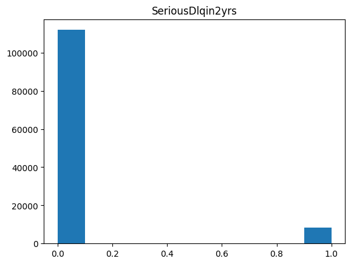

Distribution of feature variables Age is nearly normally distributed. All other variables have gamma or exponential distributions - many of them with very long tails (or rather big outliers). I am not removing this outliers (beside an outlier for age) because it's not really a part of this task.

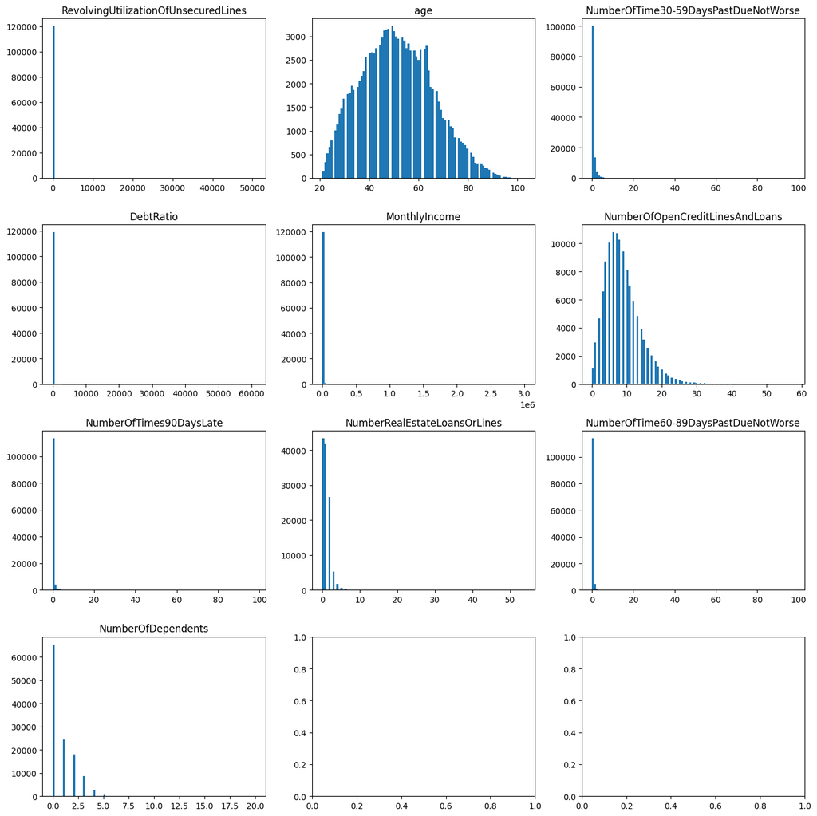

### Models and coefficients

Because for age we have nearly 100 different groups (every age has its own group) instead of calculating coefficients I provide plots showing how particular rates change among these groups. It is easy to spot on plots when there is a lack of parity.

#### First model - random forest

|  | Train | Test |
| --- | --- | --- |
| Accuracy | 0.999917 | 0.932717 |
| f1-score | 0.999395 | 0.271254 |
| Recall | 0.999032 | 0.178309 |
| ROC AUC | 0.999507 | 0.584004 |

It is visible that model discriminates especially young people. Also people of ages above 85 seem to get disproportionately a high chance of delinquency.

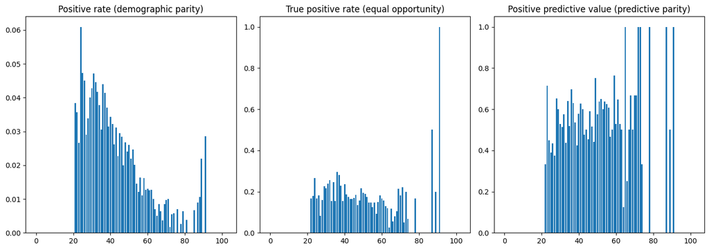

#### Second model - logistic regression

|  | Train | Test |
| --- | --- | --- |
| Accuracy | 0.931935 | 0.930572 |
| f1-score | 0.081257 | 0.078570 |
| Recall | 0.043783 | 0.042150 |
| ROC AUC | 0.520642 | 0.519913 |

People which are 20 years old are discriminated strongly by this model. For other ages fairness seems not to be better than in the previous model. At same time we need to bare in mind that logistic regression is much weaker than the random forest.

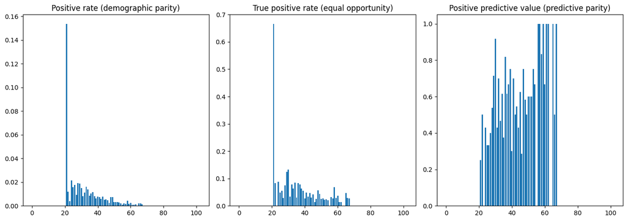

#### Additional model - random forest trained and evaluated on data without age feature

|  | Train | Test |
| --- | --- | --- |
| Accuracy | 0.999684 | 0.931902 |
| f1-score | 0.997697 | 0.272776 |
| Recall | 0.995646 | 0.181861 |
| ROC AUC | 0.997814 | 0.585207 |

I removed age column both from train and test data. Unfortunately, the change is small when comparing to the first model. It shows that age variable is not the most important one when predicting delinquency chance. Possibly it is even confusing because this model achieved better results than the first one which was using age variable.

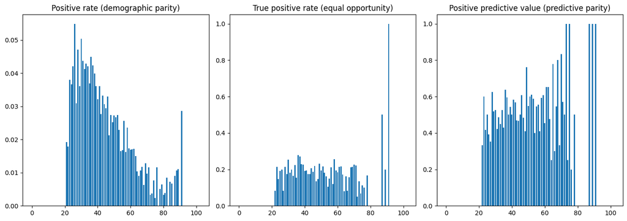

#### Third model - random forest

|  | Train | Test |
| --- | --- | --- |
| Accuracy | 0.999950 | 0.931287 |
| f1-score | 0.999637 | 0.157423 |
| Recall | 0.999516 | 0.091404 |
| ROC AUC | 0.999749 | 0.543064 |

In this model I try to mitigate bias by randomly changing deliquency prediction from 1 to 0 for people on lower and higher ends of age spectrum. In that way I was able to lower predicted delinquency rate for people younget than 35. However, this solution definitely is not perfect.

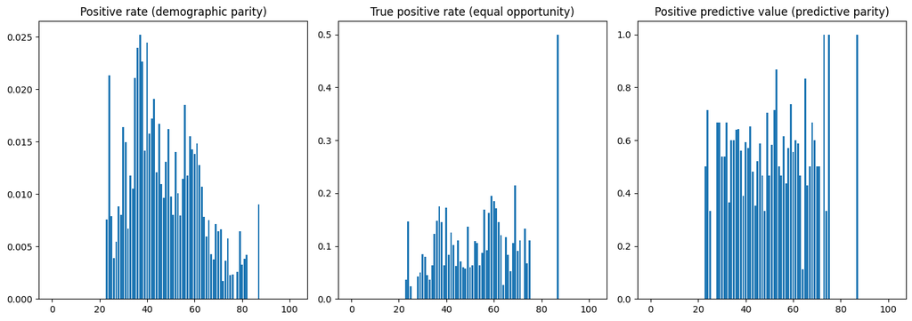

#### Models comparison and conclusions

Overall, it seems that bias reduction leads to worse model performance.

# Appendix

## Task2

```python
import pandas as pd
import numpy as np
import matplotlib.pyplot as plt
```

There are two datasets provided: cs-training and cs-test. However, target variable "SeriousDlqin2yrs" is NaN in cs-test so I cannot make model evaluation with this dataset. Therefore I will use cs-training and I will split it into train and test datasets.

```python
data = pd.read_csv("datasets/cs-training.csv", index_col=0)
print(f'There are NaN values in data:\n{data.isna().sum()}')
# We will remove them.
data.dropna(inplace=True)
```

```
There are NaN values in data:
SeriousDlqin2yrs                            0
RevolvingUtilizationOfUnsecuredLines        0
age                                         0
NumberOfTime30-59DaysPastDueNotWorse        0
DebtRatio                                   0
MonthlyIncome                           29731
NumberOfOpenCreditLinesAndLoans             0
NumberOfTimes90DaysLate                     0
NumberRealEstateLoansOrLines                0
NumberOfTime60-89DaysPastDueNotWorse        0
NumberOfDependents                       3924
dtype: int64
```

```python
display(data['age'].value_counts().sort_index())
# We can see some weird row with data for person 0 years old - let's remove it.
data = data[data['age'] >= 20]
display(data['age'].value_counts().sort_index())
```

```
age
0        1
21     130
22     329
23     515
24     652
      ...
98       3
99       3
101      2
102      2
103      2
Name: count, Length: 83, dtype: int64
```

```
age
21     130
22     329
23     515
24     652
25     797
      ...
98       3
99       3
101      2
102      2
103      2
Name: count, Length: 82, dtype: int64
```

```python
print(f'Final dataset has {data.shape[0]} rows and {data.shape[1]} columns')
display(data.head())
```

```
Final dataset has 120268 rows and 11 columns
```

|  | SeriousDlqin2yrs | RevolvingUtilizationOfUnsecuredLines | age | NumberOfTime30-59DaysPastDueNotWorse | DebtRatio | MonthlyIncome | NumberOfOpenCreditLinesAndLoans | NumberOfTimes90DaysLate | NumberRealEstateLoansOrLines | NumberOfTime60-89DaysPastDueNotWorse | NumberOfDependents |
| --- | --- | --- | --- | --- | --- | --- | --- | --- | --- | --- | --- |
| 1 | 1 | 0.766127 | 45 | 2 | 0.802982 | 9120.0 | 13 | 0 | 6 | 0 | 2.0 |
| 2 | 0 | 0.957151 | 40 | 0 | 0.121876 | 2600.0 | 4 | 0 | 0 | 0 | 1.0 |
| 3 | 0 | 0.658180 | 38 | 1 | 0.085113 | 3042.0 | 2 | 1 | 0 | 0 | 0.0 |
| 4 | 0 | 0.233810 | 30 | 0 | 0.036050 | 3300.0 | 5 | 0 | 0 | 0 | 0.0 |
| 5 | 0 | 0.907239 | 49 | 1 | 0.024926 | 63588.0 | 7 | 0 | 1 | 0 | 0.0 |

```python
from sklearn.model_selection import train_test_split

x, y = data.iloc[:, 1:], data.iloc[:, 0]
x_train, x_test, y_train, y_test = train_test_split(x, y, test_size=0.5, random_state=42)
```

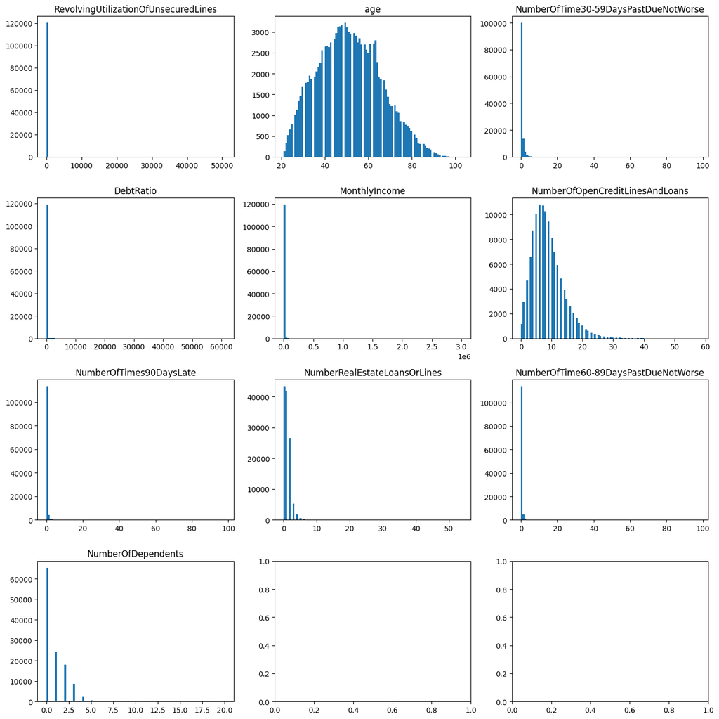

```python
fig, ax = plt.subplots(4, 3, figsize=(14, 14))
for i in range(len(x.columns)):
    ax[i // 3, i % 3].hist(x.iloc[:, i], bins=100)
    ax[i // 3, i % 3].set_title(x.iloc[:, i].name)

fig.tight_layout()
```

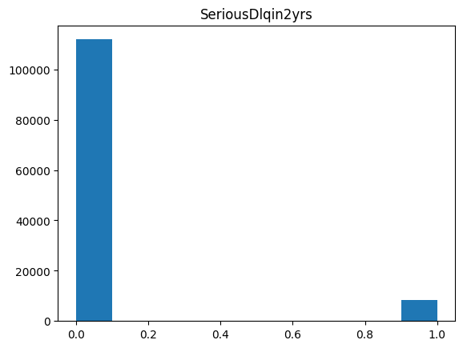

```python
plt.title(y.name)
plt.hist(y)
plt.show()
```

```python
from sklearn.metrics import accuracy_score, f1_score, recall_score, roc_auc_score

def compute_metrics(pred_train, pred_test):
    train_acc = accuracy_score(y_train[:pred_train.shape[0]], pred_train)
    train_f1 = f1_score(y_train[:pred_train.shape[0]], pred_train)
    train_recall = recall_score(y_train[:pred_train.shape[0]], pred_train)
    train_roc_auc = roc_auc_score(y_train[:pred_train.shape[0]], pred_train)

    test_acc = accuracy_score(y_test, pred_test)
    test_f1 = f1_score(y_test, pred_test)
    test_recall =  recall_score(y_test, pred_test)
    test_roc_auc = roc_auc_score(y_test, pred_test)

    display(pd.DataFrame(
        {
            'Train': [train_acc, train_f1, train_recall, train_roc_auc],
            'Test': [test_acc, test_f1, test_recall, test_roc_auc]
        },
        index=['Accuracy', 'f1-score', 'Recall', 'ROC AUC']
    ))

def compute_table_and_coefficients(y_pred):
    demographic_parity = []  # Statistical parity
    equal_opportunity = []
    predictive_parity = []
    for age in range(0, data['age'].max()):
        y_pred_for_age = y_pred[x_test['age'] == age]
        y_test_for_age = y_test[x_test['age'] == age]

        TP = np.logical_and(y_pred_for_age == 1, y_test_for_age == 1).sum()
        FP = np.logical_and(y_pred_for_age == 1, y_test_for_age == 0).sum()
        P = (y_pred_for_age == 1).sum()
        FN = np.logical_and(y_pred_for_age == 0, y_test_for_age == 1).sum()
        TN = np.logical_and(y_pred_for_age == 0, y_test_for_age == 0).sum()
        F = (y_pred_for_age == 0).sum()

        demographic_parity.append(P / len(y_pred_for_age) if len(y_pred_for_age) != 0 else 0)
        equal_opportunity.append(TP / (TP + FN) if (TP + FN) != 0 else 0)
        predictive_parity.append(TP / (TP + FP) if (TP + FP) != 0 else 0)

    age_values = list(range(len(demographic_parity)))
    fig, ax = plt.subplots(1, 3, figsize=(14, 5))
    ax[0].set_title('Positive rate (demographic parity)')
    ax[0].bar(age_values, demographic_parity)

    ax[1].set_title('True positive rate (equal opportunity)')
    ax[1].bar(age_values, equal_opportunity)

    ax[2].set_title('Positive predictive value (predictive parity)')
    ax[2].bar(age_values, predictive_parity)

    fig.tight_layout()
```

## First model

|  | Train | Test |
| --- | --- | --- |
| Accuracy | 0.999917 | 0.932717 |
| f1-score | 0.999395 | 0.271254 |
| Recall | 0.999032 | 0.178309 |
| ROC AUC | 0.999507 | 0.584004 |

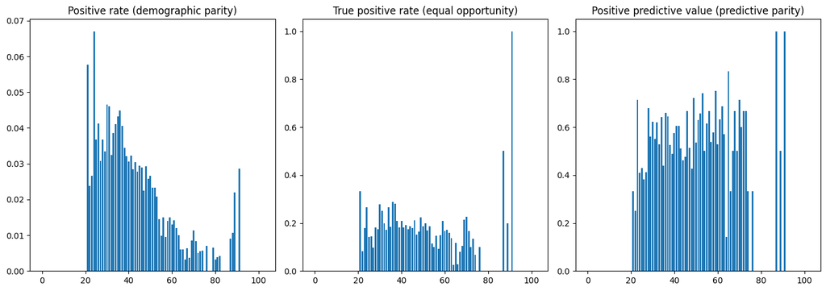

```python
from sklearn.ensemble import RandomForestClassifier

randomForest = RandomForestClassifier().fit(x_train, y_train)
y_pred = randomForest.predict(x_test)
compute_metrics(randomForest.predict(x_train), y_pred)
compute_table_and_coefficients(y_pred)
```

## Second model

|  | Train | Test |
| --- | --- | --- |
| Accuracy | 0.931935 | 0.930572 |
| f1-score | 0.081257 | 0.078570 |
| Recall | 0.043783 | 0.042150 |
| ROC AUC | 0.520642 | 0.519913 |

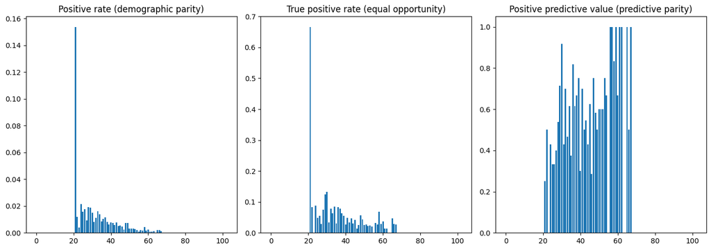

```python
from sklearn.linear_model import LogisticRegression

logisticRegression = LogisticRegression(max_iter=1000).fit(x_train, y_train)
y_pred = logisticRegression.predict(x_test)
compute_metrics(logisticRegression.predict(x_train), y_pred)
compute_table_and_coefficients(y_pred)
```

Positive rate: probability of financial distress predicted by model for a given age. True positive rate: probability of financial distress predicted by model for people who really experienced financial distress. Positive predictive value: probability of real financial distress among all financial distress model predictions.

## Model using data without age

|  | Train | Test |
| --- | --- | --- |
| Accuracy | 0.999684 | 0.931902 |
| f1-score | 0.997697 | 0.272776 |
| Recall | 0.995646 | 0.181861 |
| ROC AUC | 0.997814 | 0.585207 |

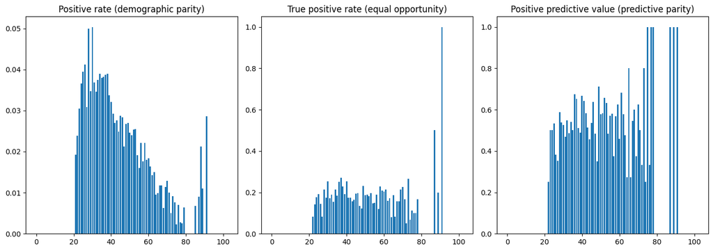

```python
randomForest = RandomForestClassifier().fit(x_train[x_train.columns.difference(['age'])], y_train)
y_pred = randomForest.predict(x_test[x_test.columns.difference(['age'])])
compute_metrics(randomForest.predict(x_train[x_train.columns.difference(['age'])]), y_pred)
compute_table_and_coefficients(y_pred)
```

## Third model

|  | Train | Test |
| --- | --- | --- |
| Accuracy | 0.999950 | 0.931287 |
| f1-score | 0.999637 | 0.157423 |
| Recall | 0.999516 | 0.091404 |
| ROC AUC | 0.999749 | 0.543064 |

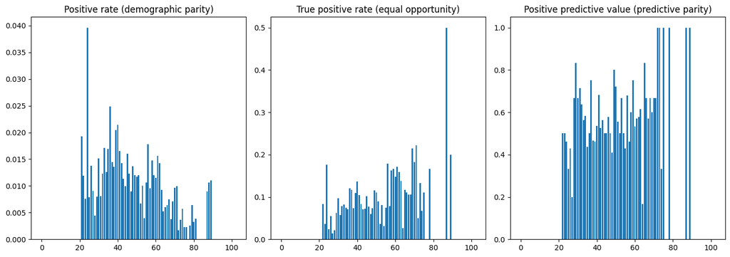

```python
randomForest = RandomForestClassifier().fit(x_train, y_train)
y_pred = randomForest.predict(x_test)
indices = np.logical_and.reduce([
    (y_pred == 1),
    (x_test['age'] < 35),
    (np.random.uniform(0, 1, y_pred.shape[0]) < 0.5)
])
y_pred[indices] = 0
indices = np.logical_and.reduce([
    (y_pred == 1),
    (x_test['age'] < 55),
    (np.random.uniform(0, 1, y_pred.shape[0]) < 0.5)
])
y_pred[indices] = 0
indices = np.logical_and.reduce([
    (y_pred == 1),
    (85 < x_test['age']),
    (np.random.uniform(0, 1, y_pred.shape[0]) < 0.5)
])
y_pred[indices] = 0
compute_metrics(randomForest.predict(x_train), y_pred)
compute_table_and_coefficients(y_pred)
```